# Spatial R Exercise 3: Spatial Dataset Interactions

*Ben Davies*

*2022-05-10*

# Part 1 Data interactions

In this exercise, we’ll look at using different types of geospatial data and how they can be made to interact in R. In this case, we’re interested how micromammal communities of southern Africa reflect different seasonal climate systems.

## 1.1 Adding packages

First, as usual, we’ll start by loading the packages we need to work with spatial data: `sf` and `terra`.

```r
#Load packages
require("sf")
require("terra")
```

# Part 2 Spatial subsetting: Vector to Raster

Here we’ll work on subsetting one spatial dataset with another. In this case, we want to use a vector dataset to set the limits of a raster dataset.

## 2.1 Load vector and raster data

Let’s use `rast` to load some data that we’ll be using to assess contemporary seasonality in southern Africa.

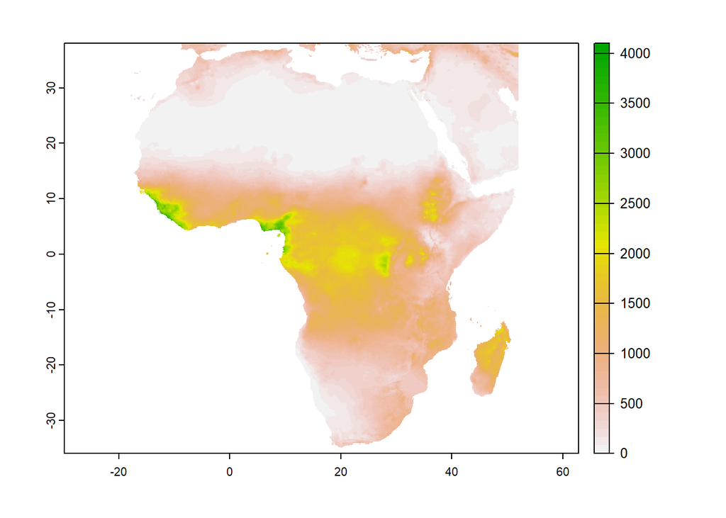

```r
#Load annual precipitation data for all of Africa
annRain<-rast("africaANNPPT.tif")
#Plot it
plot(annRain)
```

This precipitation data comes from the [Terraclimate](https://www.climatologylab.org/terraclimate.html) product, giving modeled monthly spatial averages from 1958-present. Here, the values for each year have been summed, and then these annual values are then averaged to give average annual precipitation.

However, this particular raster covers all of Africa, which is way more data that we need. We’ll import southern Africa borders shapefile to look at how we might subset it.

```r
saBorders<-st_read("south_africa_border.shp")
```

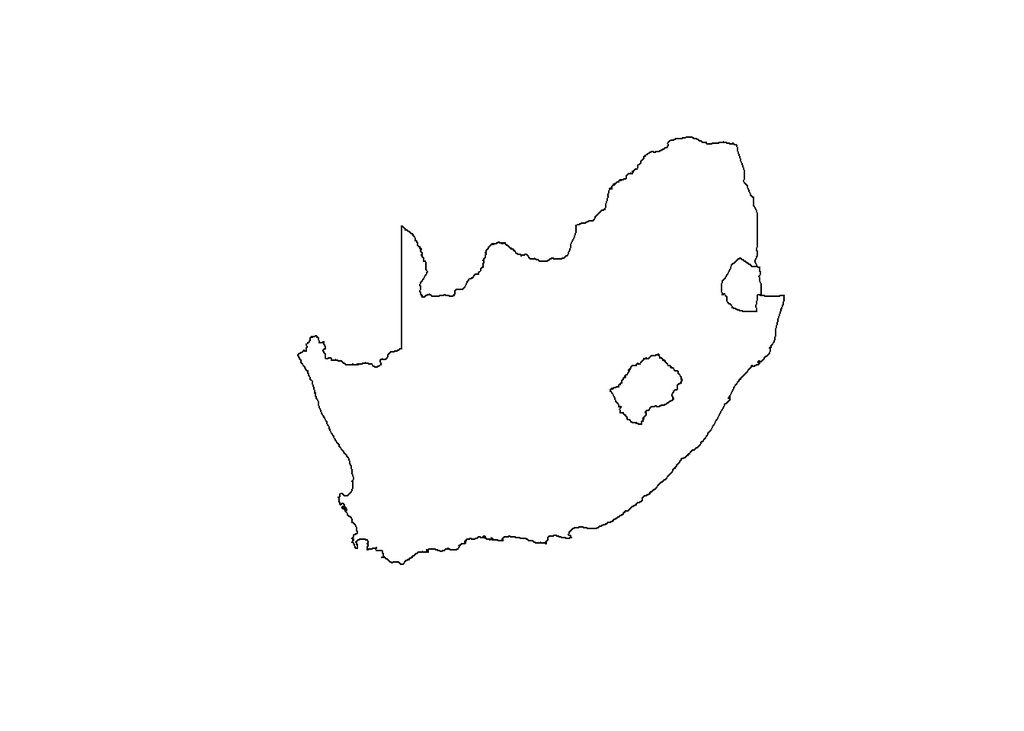

```r
plot(st_geometry(saBorders))
```

## 2.2 Crop raster with vector data

Now that we have a raster and a vector dataset, we’ll use the latter to spatially subset the former. To do this, we will need the `crop` function.

```r
#Crop rainfall data to southern Africa
saAnnRain<-crop(annRain,saBorders)
```

The first argument to the crop function is the raster we want crop (`annRain`). The second is the object we are using to set the new margins (`saBorders`).

Now we can take a look…

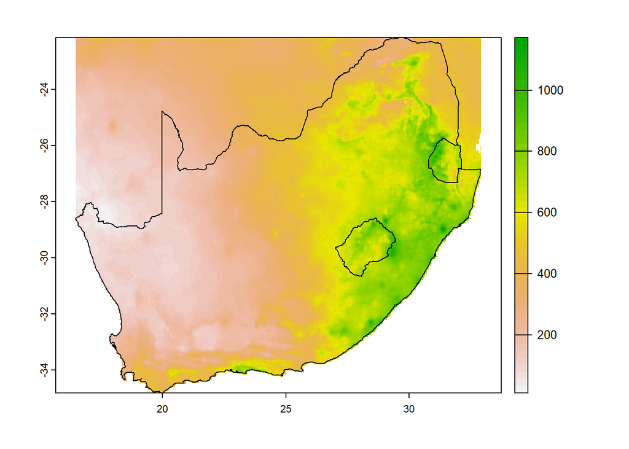

```r
#Plot new raster and borders
plot(saAnnRain)
plot(st_geometry(saBorders),add=T)
```

Hmmm… this looks OK, but maybe not exactly what we wanted since the rainfall values extend beyond the area of interest. The main reason for this is that we used an `sf` object as the cropping object. When `terra` tries to do this, it can only crop to the extent of the object.

In order to crop more closely, we need to turn our `saBorders` object into a `terra` SpatVector object, which is a format `terra` uses to represnt vector data. We can use the `vect` function for this:

```r
#Turn sf object into a SpatVector dataset
saBordersSF<-vect(saBorders)
saBordersSF
```

```
##  class       : SpatVector
##  geometry    : polygons
##  dimensions  : 3, 94  (geometries, attributes)
##  extent      : 16.46998, 32.89308, -34.82195, -22.12645  (xmin, xmax, ymin, ymax)
##  coord. ref. : lon/lat WGS 84 (EPSG:4326)
##  names       :      featurecla scalerank LABELRANK   SOVEREIGNT SOV_A3 ADM0_DIF
##  type        :           <chr>     <int>     <int>        <chr>  <chr>    <int>
##  values      : Admin-0 country         0         2 South Africa    ZAF        0
##                Admin-0 country         0         4     eSwatini    SWZ        0
##                Admin-0 country         0         6      Lesotho    LSO        0
##  LEVEL              TYPE        ADMIN ADM0_A3 (and 84 more)
##  <int>             <chr>        <chr>   <chr>
##      2 Sovereign country South Africa     ZAF
##      2 Sovereign country     eSwatini     SWZ
##      2 Sovereign country      Lesotho     LSO
```

OK, now we have the borders as a SpatVector. We can plug this in and see what we get:

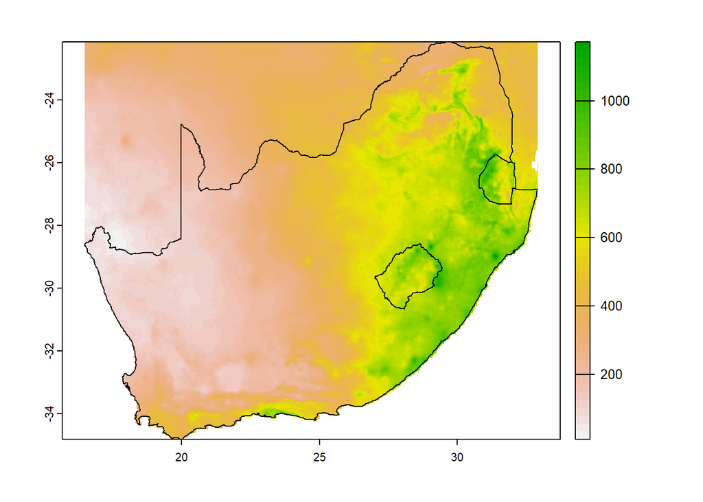

```r
#Crop rain data again with SpatVector
saAnnRain<-crop(annRain,saBordersSF)
plot(saAnnRain)
plot(st_geometry(saBorders),add=T)
```

Still not quite there! The last step is that we need add the `mask` argument to the `crop` function and set it to true. This tells `crop` to take any values outside the cropping object and convert them to `NA` values.

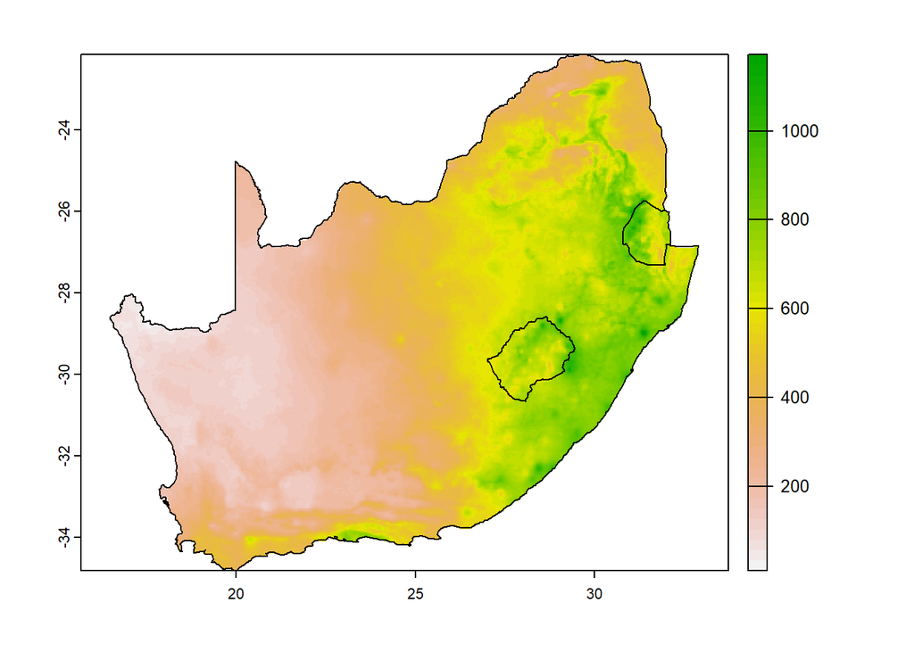

```r
#Crop rain data again with SpatVector
saAnnRain<-crop(annRain,saBordersSF,mask=T)
plot(saAnnRain)
plot(st_geometry(saBorders),add=T)
```

There we go! That looks much better. Let’s use `global` to get a sense of the average and standard deviation on this new raster.

```r
#Get some stats
global(saAnnRain,"mean")
```

```
##              mean
## africaAnnPPT  NaN
```

```r
global(saAnnRain,"sd")
```

```
##               sd
## africaAnnPPT NaN
```

Ack! When we see `NaN`, that stands for “not a number”. That means R tried to do something mathematically impossible. The problem here is that, since we used `mask` to carve out our raster, there are now lots of `NA` values in the raster, and R can’t calculate statistics when these values are present. We can use `na.rm` to get rid of them.

```r
#Get some stats
global(saAnnRain,"mean",na.rm=TRUE)
```

```
##                 mean
## africaAnnPPT 439.047
```

```r
global(saAnnRain,"sd",na.rm=TRUE)
```

```
##                    sd
## africaAnnPPT 228.5005
```

## 2.3 Try it yourself!

- It’s very easy to make histograms out of raster data. See if you can make a histogram out of the rainfall data for southern Africa and then all of Africa. How do they compare?
- Can you create a boolean raster for places in southern Africa that get more than the mean rainfall?

# Part 3 Spatial subsetting: Raster to Raster

This time, we’re going to use a raster data to perform a spatial subset on another raster. This should be a little more straightforward since we aren’t trying to make `sf` and `terra` talk to eachother.

## 3.1 Add more raster data

Here we’ll add another Terraclimate-derived dataset.

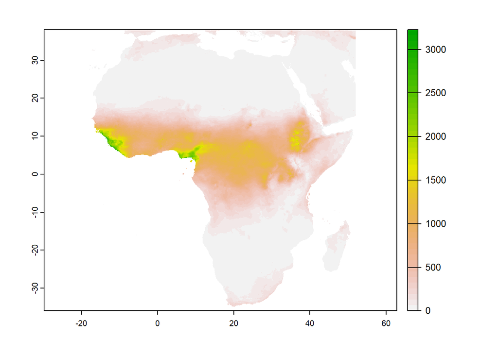

```r
#Import winter rainfall
winRain<-rast("africaWinPPT.tif")

#Plot it
plot(winRain)
```

This is just like the annual average rainfall data, but only for the winter months (June, July, and August).

Since our annual rainfall data has already been cropped, we should be able to use that data to crop our new dataset.

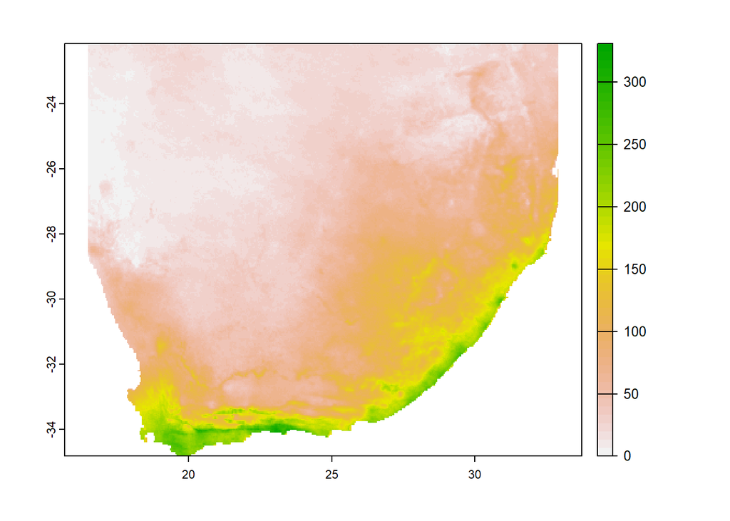

```r
#Crop winter rain using annual rain
saWinRain<-crop(winRain,saAnnRain,mask=TRUE)

#Plot it
plot(saWinRain)
```

This again! The problem here is that the `mask` argument here only applies to a SpatVector object like we made in the previous section. If we want to use a raster to mask another raster, we need to call the `mask` function:

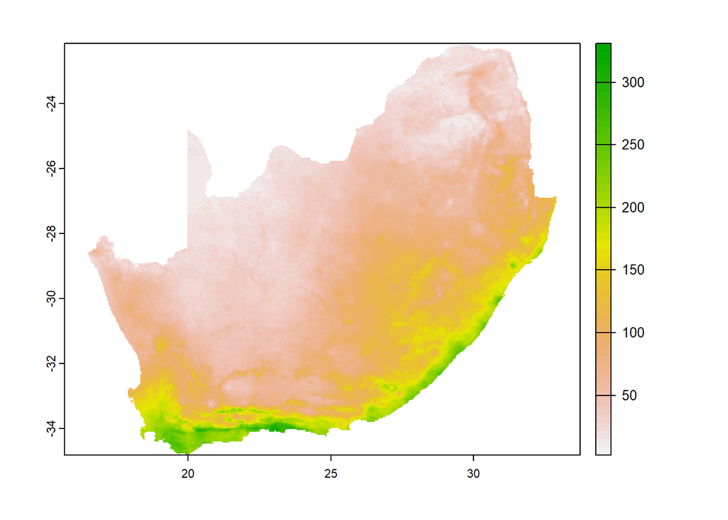

```r
#Crop it again
saWinRain<-crop(winRain,saAnnRain)

#Mask the winter rain data with the annual rain data
saWinRain<-mask(saWinRain,saAnnRain)

#Plot it
plot(saWinRain)
```

OK, great!

## 3.2 Raster algebra revisited

OK, for this last step, we want to know what percentage of an area’s rainfall occurs in the winter. This will give us a sense of seasonality across southern Africa. To get this all we have to do is divide the winter rainfall values by the total annual values:

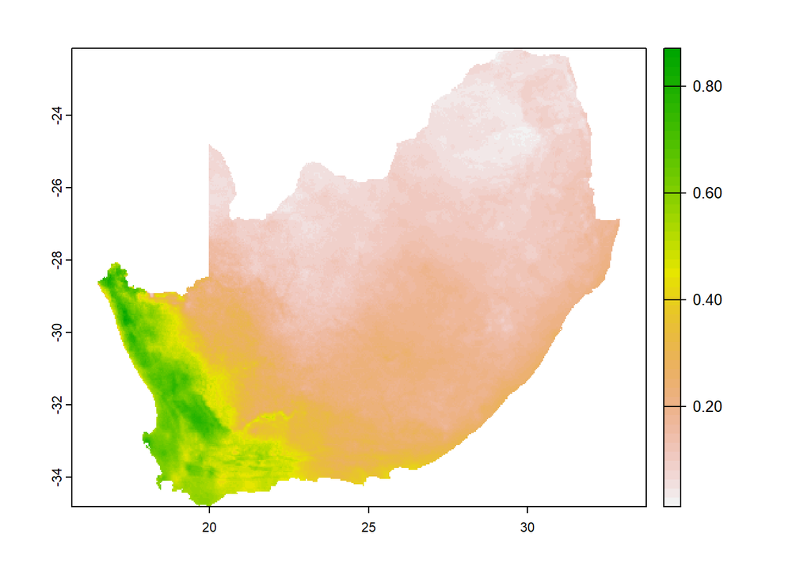

```r
#Get winter percentages
winRainPercent<-saWinRain/saAnnRain

#Plot it
plot(winRainPercent)
```

Cool! Hopefully from this map you can see southern Africa’s very distinctive winter and summer rainfall zones.

# Part 4 Spatial subsetting: Vector to Vector

The last spatial subsetting we’ll do is using one vector to subset another.

## 4.1 Convert table data to vector data

First let’s bring in some table data with spatial coordinates:

```r
micro<-read.csv("micromammals.csv")
head(micro)
```

```
##                         Site Abbreviation Latitude Longitude CODE        ORDER
## 1 100 Elliott Street Kokstad          ESK   -30.54     29.41 CCYA SORICOMORPHA
## 2 100 Elliott Street Kokstad          ESK   -30.54     29.41 CFLA SORICOMORPHA
## 3 100 Elliott Street Kokstad          ESK   -30.54     29.41 DINC     RODENTIA
## 4 100 Elliott Street Kokstad          ESK   -30.54     29.41 MMIN     RODENTIA
## 5 100 Elliott Street Kokstad          ESK   -30.54     29.41 MMUS     RODENTIA
## 6 100 Elliott Street Kokstad          ESK   -30.54     29.41 MNAT     RODENTIA
##      FAMILY    SUBFAMILY     GENUS       SPECIES                   COMMONNAME
## 1 Soricidae Crocidurinae Crocidura        cyanea      Reddish-gray Musk Shrew
## 2 Soricidae Crocidurinae Crocidura    flavescens       Greater Red Musk Shrew
## 3   Muridae      Murinae  Dasymys  incomtus s.l.               Common Dasymys
## 4   Muridae      Murinae      Mus     minutoides Southern African Pygmy Mouse
## 5   Muridae      Murinae      Mus       musculus                  House Mouse
## 6   Muridae      Murinae Mastomys     natalensis               Natal Mastomys
```

These are modern micromammal occurrences that were used in this paper:

Faith, J. Tyler, Brian M. Chase, and D. Margaret Avery. 2019. “Late Quaternary Micromammals and the Precipitation History of the Southern Cape, South Africa.” Quaternary Research 91 (2): 848–60. https://doi.org/10.1017/qua.2018.105.

The information includes the site, the coordinates, and the species encountered. In order to make use of it in our analysis, we need to turn it into vector data.

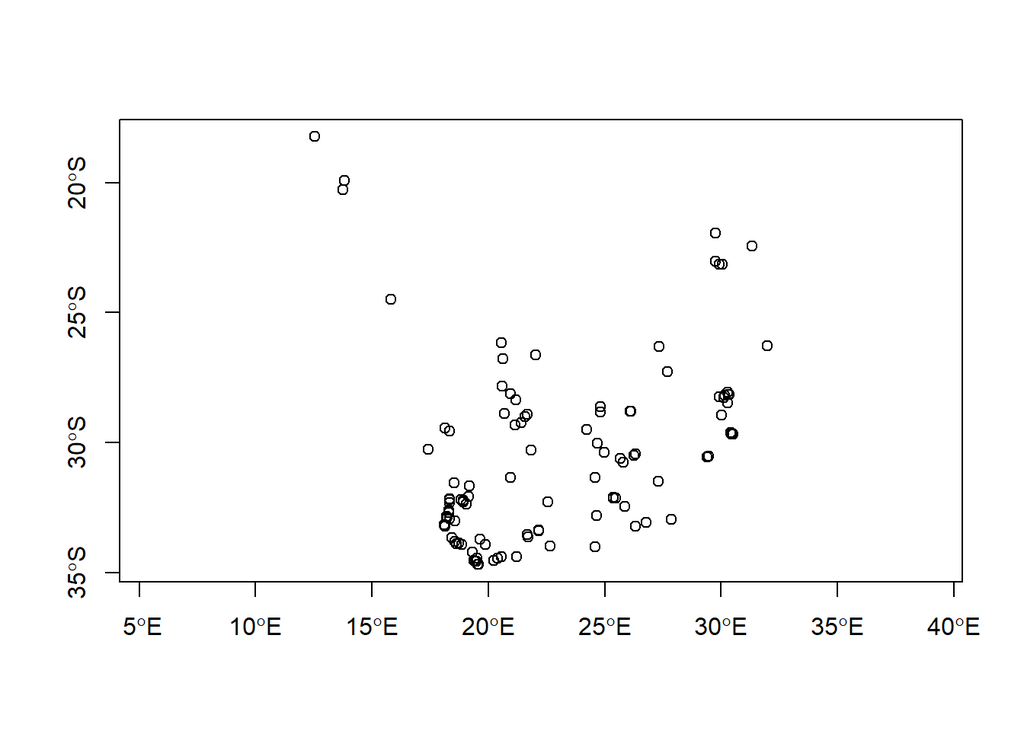

```r
microSF<-st_as_sf(micro,coords=c("Longitude","Latitude"),crs=4326)
plot(st_geometry(microSF),axes=T)
```

## 4.2 Cropping vector to vector

The way to crop one vector dataset with another is to use the `st_crop` function.

```r
#Crop micromammal dataset to southern Africa
micromammals<-st_crop(microSF,saBorders)
```

```
## Warning: attribute variables are assumed to be spatially constant throughout all
## geometries
```

Imagine if you were using this function to crop a polygon that represented grassland vegetation. This wouldn’t be problematic, because the cropped polygon would still be grassland. However, now imagine that you used it to crop the polygon for Lesotho, which contains a population estimate. That population estimate would no longer be valid for the cropped section of Lesotho.

Here, we’re not really worried about this because we’re pruning points, so there isn’t any cutting of individual features. Let’s take a look.

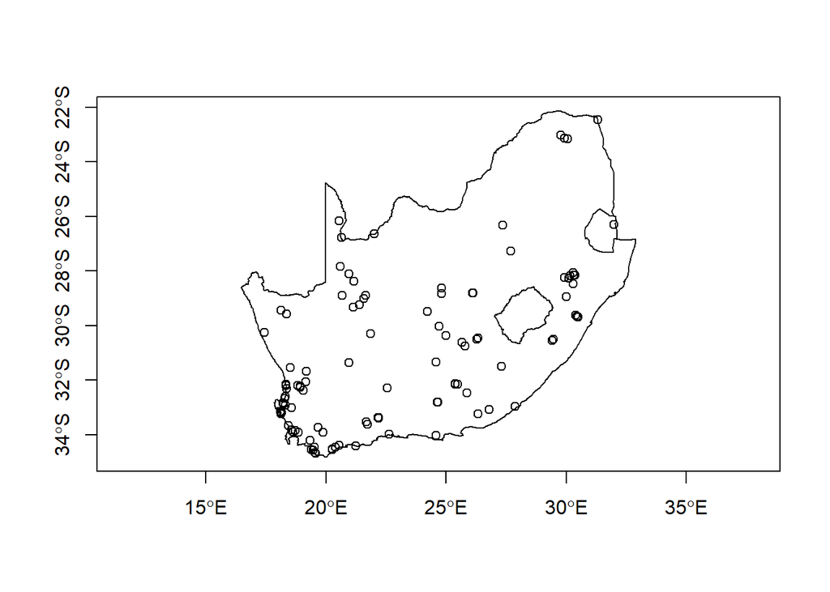

```r
#Plot borders and micromammals
plot(st_geometry(saBorders),axes=T)
plot(st_geometry(micromammals),add=T)
```

Looks good!

## 4.3 Try it yourself

- Create a plot that shows the borders, but instead of just the micromammal point locations, plot them by genus (hint: this may involve square brackets).
- Change the symbol shape with the `pch` argument (it takes an integer and defaults to 1).

# Part 5 Spatial Sampling

For this final step, we’re going to use our micromammal vector data to sample our raster data on rainfall seasonality.

## 5.1 Extract point values

To accomplish this, we need to use `extract`, which we’ve seen before. In that instance, we used a matrix of XY values. Here, we want to use the locations of our micromammals. To use it here with our SpatRaster object, we need to make it into a SpatVector object with `vect`.

```r
winRainMM<-extract(winRainPercent,vect(micromammals))
head(winRainMM)
```

```
##   ID africaWinPPT
## 1  1    0.1719577
## 2  2    0.1719577
## 3  3    0.1719577
## 4  4    0.1719577
## 5  5    0.1719577
## 6  6    0.1719577
```

Great! This is a dataframe with our winter rainfall percentage data. Notice it takes it’s name from the original winter rainfall dataset that we read in earlier.

Now we just want to tack this on to our micromammal dataset. To do this, we’ll first turn the table above into a vector of values, and then use `cbind` to add that vector as a new column.

```r
#Add this column back to the micromammal data
WR<-winRainMM$africaWinPPT
micromammals<-cbind(micromammals,WR)
micromammals
```

```
## Simple feature collection with 1482 features and 10 fields
## Geometry type: POINT
## Dimension:     XY
## Bounding box:  xmin: 17.43 ymin: -34.69 xmax: 31.98 ymax: -22.45
## Geodetic CRS:  WGS 84
## First 10 features:
##                          Site Abbreviation CODE        ORDER    FAMILY
## 1  100 Elliott Street Kokstad          ESK CCYA SORICOMORPHA Soricidae
## 2  100 Elliott Street Kokstad          ESK CFLA SORICOMORPHA Soricidae
## 3  100 Elliott Street Kokstad          ESK DINC     RODENTIA   Muridae
## 4  100 Elliott Street Kokstad          ESK MMIN     RODENTIA   Muridae
## 5  100 Elliott Street Kokstad          ESK MMUS     RODENTIA   Muridae
## 6  100 Elliott Street Kokstad          ESK MNAT     RODENTIA   Muridae
## 7  100 Elliott Street Kokstad          ESK MVAR SORICOMORPHA Soricidae
## 8  100 Elliott Street Kokstad          ESK OIRR     RODENTIA   Muridae
```

[output cut: 24 more lines]

We did it! Now we can start to look at the seasonality of different species niches. First, let’s plot the data:

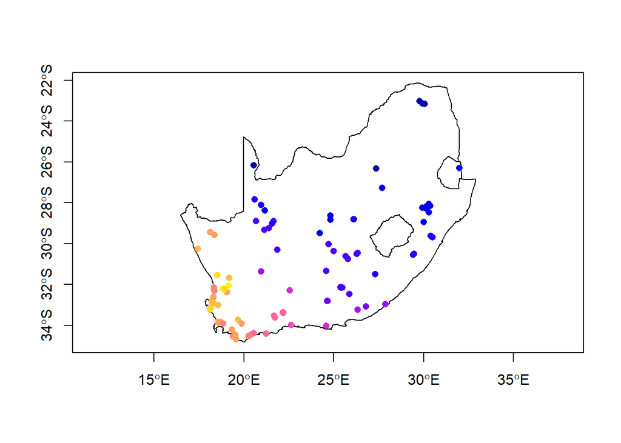

```r
#Plot borders and micromammals by their winter rainfall percentage
plot(st_geometry(saBorders),axes=T)
plot(micromammals['WR'],add=T,pch=16)
```

We can use `subset` to look at specific micromammals. Here’s the [house mouse](https://animalia.bio/house-mouse):

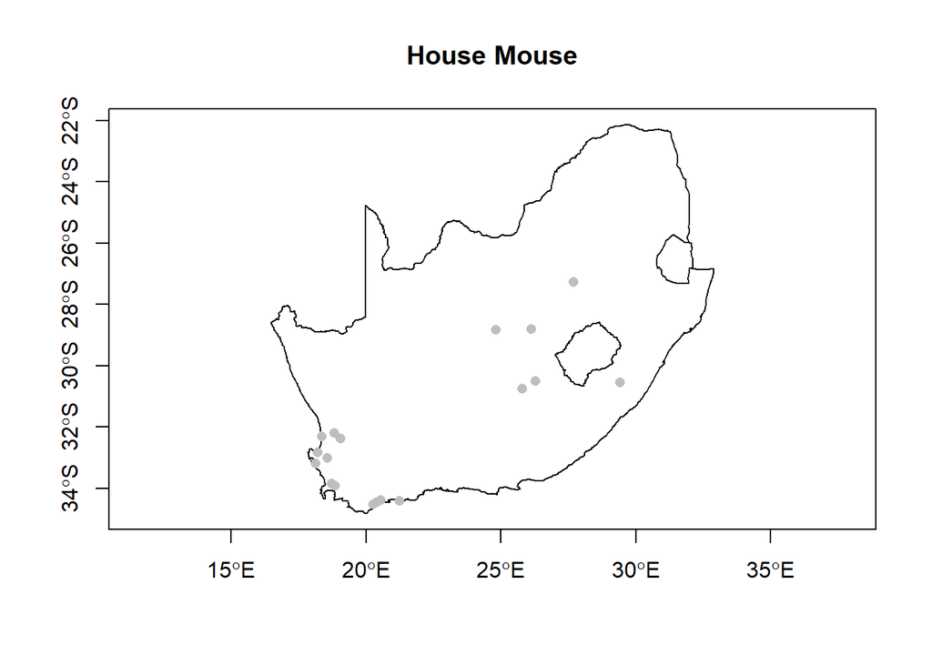

```r
#Plot house mouse rainfall
houseMouse<-subset(micromammals,COMMONNAME=="House Mouse")
plot(st_geometry(saBorders),axes=T,main="House Mouse")
plot(st_geometry(houseMouse),add=T,pch=16,col="gray")
```

And here’s the [singe striped lemniscomys](https://animalia.bio/single-striped-grass-mouse) (grass mouse):

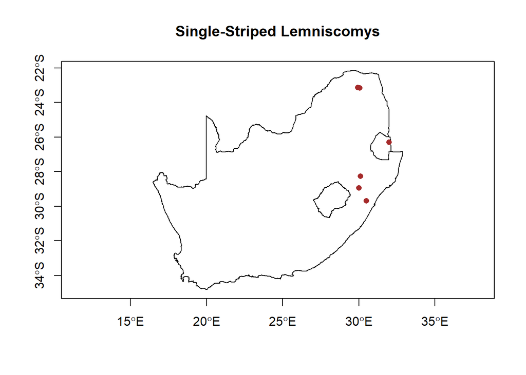

```r
lemniscomys<-subset(micromammals,COMMONNAME=="Single-Striped Lemniscomys")
plot(st_geometry(saBorders),axes=T,main="Single-Striped Lemniscomys")
plot(st_geometry(lemniscomys),add=T,pch=16,col="brown")
```

Finally, we can use this data to compare these species. Here’s a `boxplot` for these two species.

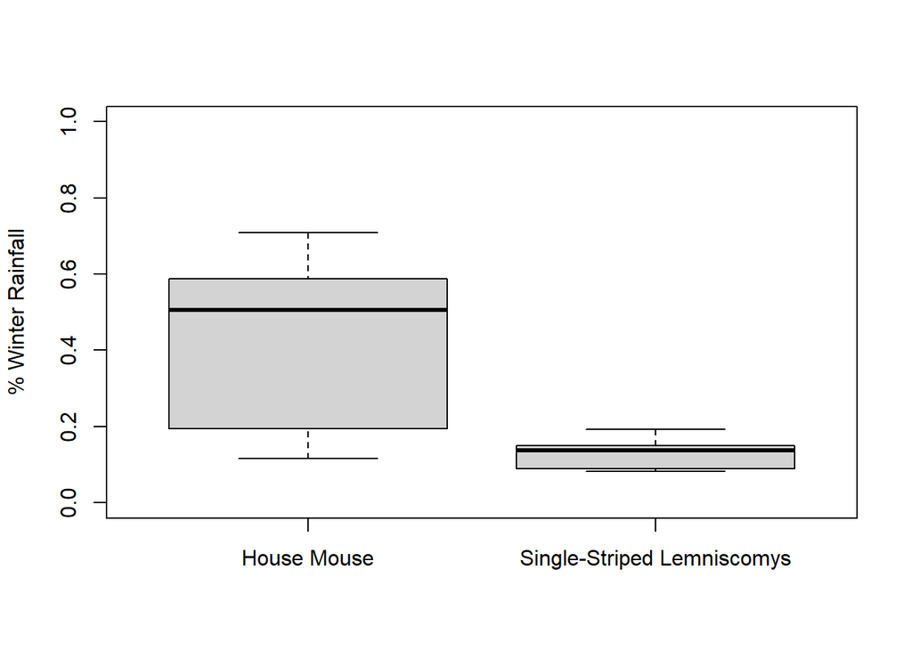

```r
boxplot(houseMouse$WR,lemniscomys$WR,names=c("House Mouse","Single-Striped Lemniscomys"),ylim=c(0,1),ylab="% Winter Rainfall")
```

# Part 6 Bring it all together

OK, we’ve managed to look at this across southern Africa, but what if we wanted to limit our analysis a single country? The answer: subsetting! * Can you subset the borders data to include only Lesotho? * Can you then spatially subset the annual and winter rainfall data to Lesotho? Can you get the percentage of winter rainfall for Lesotho? The subsetting methods are up to you, but make sure you plot all with axes. * Can you get a histogram of Lesotho annual rainfall?